# miaR_babynames

The first step is to load necessary packages and the data

```r
library(tidyverse)
library(gridExtra)

load("../data/babynames.rda")
head(babynames)
```

```
## # A tibble: 6 x 5
##    year sex   name          n   prop
##   <dbl> <chr> <chr>     <int>  <dbl>
## 1  1880 F     Mary       7065 0.0724
## 2  1880 F     Anna       2604 0.0267
## 3  1880 F     Emma       2003 0.0205
## 4  1880 F     Elizabeth  1939 0.0199
## 5  1880 F     Minnie     1746 0.0179
## 6  1880 F     Margaret   1578 0.0162
```

Warm-up: taking a look at my own name

```r
babynames %>%
  filter(year==2002, name=="Mia")
```

```
## # A tibble: 2 x 5
##    year sex   name      n       prop
##   <dbl> <chr> <chr> <int>      <dbl>
## 1  2002 F     Mia    6257 0.00317
## 2  2002 M     Mia      10 0.00000484
```

Creating a function to graph the sex distribution of names over time

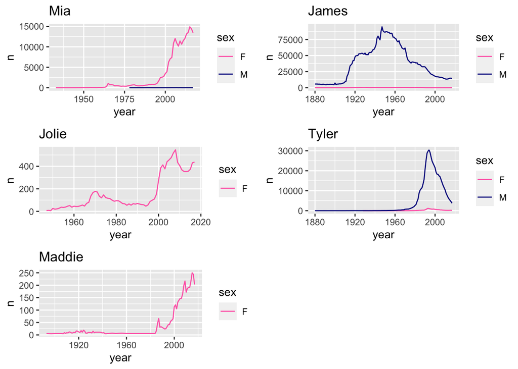

```r
gg_name <- function(idname = NULL, color1 = NULL, color2 = NULL) {
  p <- ggplot(babynames %>% filter(name==idname),
              aes(x=year, y=n, color=sex)) +
    geom_line(color1="hotpink", color1="darkblue") +
    ggtitle(idname) +
    scale_color_manual(values=c(color1,color2))
  return(p)
}

grid.arrange(
  gg_name("Mia", color1 = "hotpink", color2 = "darkblue"),
  gg_name("James", color1 = "hotpink", color2 = "darkblue"),
  gg_name("Jolie", color1 = "hotpink", color2 = "darkblue"),
  gg_name("Tyler", color1 = "hotpink", color2 = "darkblue"),
  gg_name("Maddie", color1 = "hotpink", color2 = "darkblue")
  )
```

Now for a little bit of data carpentry. First, I narrowed down the criteria that I wanted to work with by using filter(). I chose to work with babynames from the year 2002 — my birth year. After this, I am essentially creating a separate M and F column instead of having a sex column, where each name has an M and F row

```r
df <- babynames %>%
  filter(year == 2002) %>%
  group_by(name, sex) %>%
  summarize(total = sum(n)) %>%
  pivot_wider(
  names_from = sex, values_from = total, values_fill = 0)
```

I am changing M and F to nM and nF so R does not confuse F with FALSE. Next, I am adding to the dataset by creating a total column that includes the number of births (both M and F) for every name and the sex ratio. To find more unisex names, I filtered the output to have ratios between 0.33 and 0.67

```r
colnames(df) <- c("name", "nM", "nF")
df <- df %>% mutate(ratio = nM/nF, total = nM + nF)
unisex_names <- df %>%
  filter(ratio > .33, ratio < .67, total > 250)
unisex_names
```

```
## # A tibble: 14 x 5
## # Groups:   name [14]
##    name         nM    nF ratio total
##    <chr>     <int> <int> <dbl> <int>
##  1 Avery      1387  2588 0.536  3975
##  2 Dominique   378   829 0.456  1207
##  3 Harley      577   871 0.662  1448
##  4 Jalyn       105   283 0.371   388
##  5 Loren       126   224 0.562   350
##  6 Mckinley     99   169 0.586   268
##  7 Montana     124   366 0.339   490
##  8 Nikita       76   206 0.369   282
##  9 Presley     132   362 0.365   494
## 10 Reilly      204   305 0.669   509
## 11 Robin       122   271 0.450   393
## 12 Sage        380   683 0.556  1063
## 13 Teagan      151   411 0.367   562
## 14 Tracy       118   283 0.417   401
```

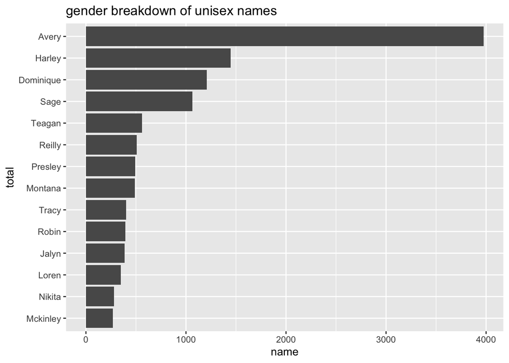

```r
ggplot(unisex_names, aes(x=reorder(name, total), y=total)) +
  geom_col() +
  coord_flip() +
  xlab("total") +
  ylab("name") +
  ggtitle("gender breakdown of unisex names")
```

Work on separating bars into nM and nF